# Geography-independent mucosal microbiota alterations in primary sclerosing cholangitis persist after liver transplantation

Additional disease control

# 1 Introduction

**PSC vs ALD**

In previous analyses, we showed specific mucosal composition in PSC patients which persist after liver transplantation. Here, we added another positive control, to explore if this condition is disease specific, or it can be credited to (liver) disease in general.

Fo this purpose, we conduct the univariate analysis on Czech ALD patients after LTx. By comparing post_LTx PSC and ALD patients, we can check if the proposed PSC-associated bacteria are at least partially overlapping.

If so, this would confirm our previous conclusions that these bacteria are specific for PSC.

**Importing libraries and custom functions built for this analysis**

```r
source("custom_functions.R")
```

# 2 Data Import

Importing ASV, taxa and metadata tables for both Czech ALD samples samples.

```r
path = "../../../../data/analysis_ready_data/ikem/ALD/"
asv_tab_ALD <- as.data.frame(fread(file.path(path,"asv_table_ALD.tsv"),
                                    check.names = FALSE))
taxa_tab_ALD <- as.data.frame(fread(file.path(path,"taxa_table_ALD.tsv"),
                                     check.names = FALSE))
metadata_ALD <- as.data.frame(fread(file.path(path,"metadata_ALD.tsv"),
                                     check.names = FALSE))
```

Importing previous Czech dataset with PSC patients.

```r
path = "../../../../data/analysis_ready_data/ikem/"
asv_tab_ikem <- as.data.frame(fread(file.path(path,"asv_table_ikem.csv"),
                                    check.names = FALSE))
taxa_tab_ikem <- as.data.frame(fread(file.path(path,"taxa_table_ikem.csv"),
                                     check.names = FALSE))
metadata_ikem <- as.data.frame(fread(file.path(path,"metadata_ikem.csv"),
                                     check.names = FALSE))
```

Importing proposed PSC-associated taxa.

```r
psc_genus_ti <- read.xlsx("../../../results/merged_sites/main_analysis/Q1/univariate_analysis/psc_effect_terminal_ileum.xlsx")

psc_genus_colon <- read.xlsx("../../../results/merged_sites/main_analysis/Q1/univariate_analysis/psc_effect_colon.xlsx")
```

# 3 Terminal ileum

```r
segment="terminal_ileum"

ileum_data <- merging_data(asv_tab_1=asv_tab_ALD,
                           asv_tab_2=asv_tab_ikem,
                           taxa_tab_1=taxa_tab_ALD,
                           taxa_tab_2=taxa_tab_ikem,
                           metadata_1=metadata_ALD,
                           metadata_2=metadata_ikem,
                           segment="TI",Q="QALD")
```

```
Removing 630 ASV(s)
```

```
Removing 1498 ASV(s)
```

```
Merging at ASV level
```

```
Finding inconsistencies in taxonomy, trying to keep the ones that have better taxonomy assignment
```

```
Removing 223 ASV(s)
```

```r
ileum_asv_tab <- ileum_data[[1]]
ileum_taxa_tab <- ileum_data[[2]]
ileum_metadata <- ileum_data[[3]]
```

## 3.1 Filtering

Rules:

- sequencing depth > 10000
- nearZeroVar() with default settings

**Library size**

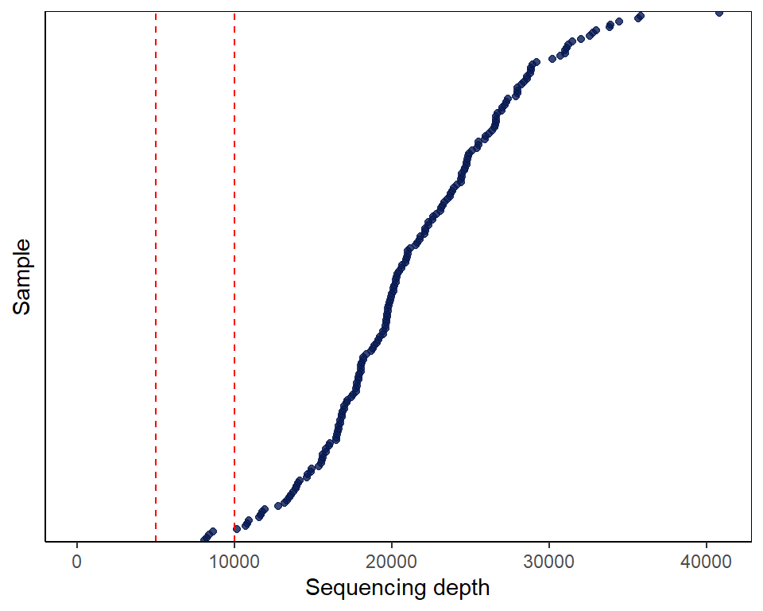

```r
read_counts(ileum_asv_tab, line = c(5000,10000))
```

### 3.1.1 Sequencing depth

```r
data_filt <- seq_depth_filtering(ileum_asv_tab,
                                 ileum_taxa_tab,
                                 ileum_metadata,
                                 seq_depth_threshold = 10000)
```

```
Removing 50 ASV(s)
```

```r
filt_ileum_asv_tab <- data_filt[[1]]; alpha_ileum_asv_tab <- filt_ileum_asv_tab
filt_ileum_taxa_tab <- data_filt[[2]]; alpha_ileum_taxa_tab <- filt_ileum_taxa_tab
filt_ileum_metadata <- data_filt[[3]]; alpha_ileum_metadata <- filt_ileum_metadata

seq_step <- dim(filt_ileum_asv_tab)[1]
```

**Library size**

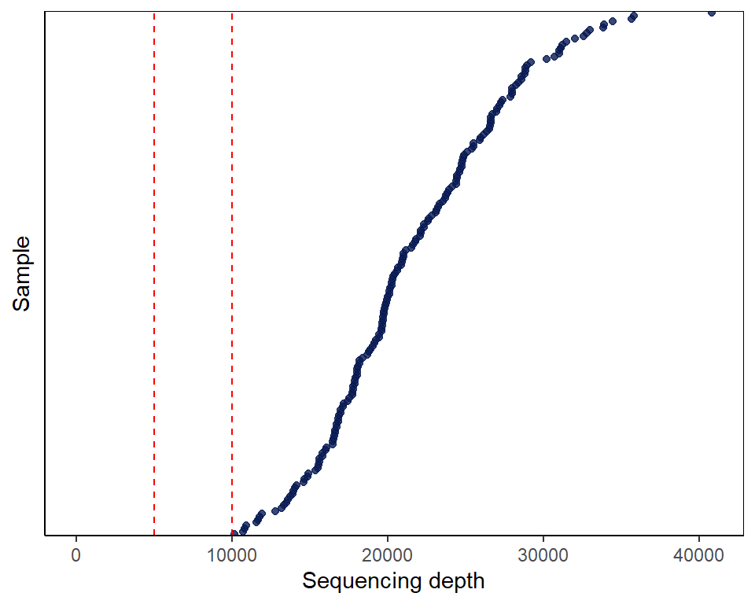

```r
read_counts(filt_ileum_asv_tab,line = c(5000,10000))
```

### 3.1.2 NearZeroVar

```r
data_filt <- nearzerovar_filtering(filt_ileum_asv_tab,
                                   filt_ileum_taxa_tab,
                                   filt_ileum_metadata)

filt_ileum_asv_tab <- data_filt[[1]]
filt_ileum_taxa_tab <- data_filt[[2]]
nearzero_step <- dim(filt_ileum_asv_tab)[1]
```

Library size

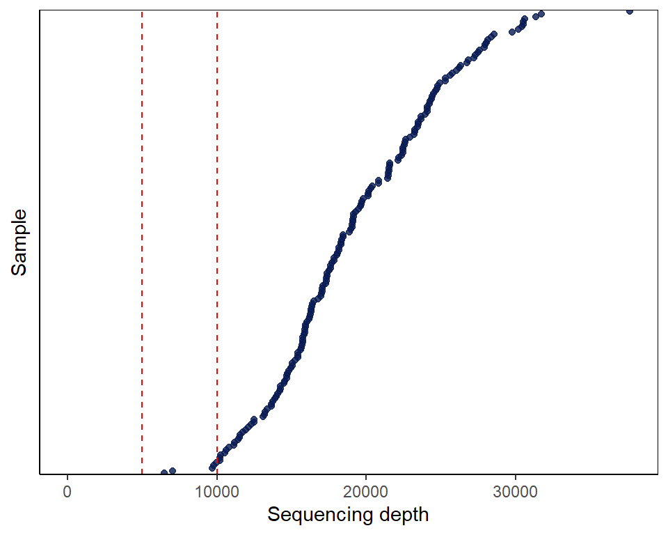

```r
read_counts(filt_ileum_asv_tab,line = c(5000,10000))
```

### 3.1.3 Final Counts

```r
final_counts_filtering(ileum_asv_tab,
                       filt_ileum_asv_tab,
                       filt_ileum_metadata,
                       seq_step, 0, nearzero_step) %>% `colnames<-`("Count")
```

```
                            Count
Raw data: ASVs               3982
Raw data: Samples             185
Sequencing depth filt: ASVs  3932
Prevalence filt: ASVs           0
NearZeroVar filt: ASVs        708
Filt data: ASVs               708
Filt data: Samples            181
Filt data: Patients           181
Filt data: Patients.1           0
Filtered samples                4
Matrices                       TI
healthy                         0
non-rPSC                        0
rPSC                            0
pre_ltx                         0
post_ltx                        0
ETOH                            0
```

## 3.2 Alpha diversity

```r
path = "../../../results/merged_sites/main_analysis/QALD/alpha_diversity"
```

**Calculation**

```r
# Construct MPSE object
alpha_ileum_metadata$Sample <- alpha_ileum_metadata$SampleID
ileum_mpse <- as.MPSE(construct_phyloseq(alpha_ileum_asv_tab,
                                         alpha_ileum_taxa_tab,
                                         alpha_ileum_metadata))

ileum_mpse %<>% mp_rrarefy(raresize = 10000,seed = 123)

# Calculate alpha diversity - rarefied counts
ileum_mpse %<>% mp_cal_alpha(.abundance=RareAbundance, force=TRUE)
```

```r
alpha_div_plots <- list()

# preparing data frame
alpha_data <- data.frame(SampleID=ileum_mpse$Sample.x,
                         Observe=ileum_mpse$Observe,
                         Shannon=ileum_mpse$Shannon,
                         Simpson=ileum_mpse$Simpson,
                         Pielou=ileum_mpse$Pielou,
                         Group=ileum_mpse$Group,
                         Country=ileum_mpse$Country,
                         Patient=ileum_mpse$Patient)

write.csv(alpha_data,file.path(path,paste0("alpha_indices_",segment,".csv")),
          row.names = FALSE)
```

### 3.2.1 Plots

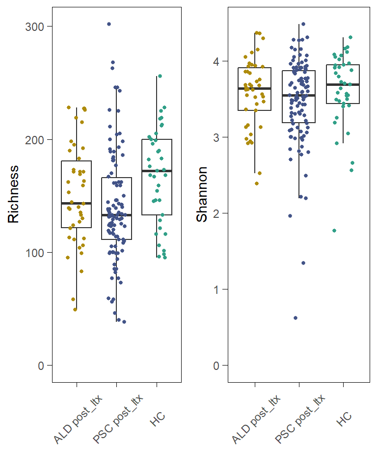

```r
p_boxplot_alpha <- alpha_diversity_countries(alpha_data,
                                             show_legend = FALSE,
                                             size=1,gap=FALSE,jitter=1.5)
# save the results
alpha_div_plots[[paste(segment,"Country")]] <- p_boxplot_alpha

# see the results
p_boxplot_alpha
```

### 3.2.2 Linear Model

```r
path = "../../../results/merged_sites/main_analysis/QALD/alpha_diversity"
alpha_data <- read.csv(file.path(path,paste0("alpha_indices_",segment,".csv")))
```

**Richness**

```r
results_model <- pairwise.lm(formula = "Observe ~ Group",
                             factors=alpha_data$Group,
                             data=alpha_data)

# check interaction
if (!is.data.frame(results_model)){
  results_model_observe <- results_model[[1]]
  results_model_observe_emeans <- results_model[[2]]
} else {
  results_model_observe <- results_model
  results_model_observe_emeans <- NA
}

# save the results
pc_observed <- list();
pc_observed[[segment]] <- results_model_observe
```

```r
# see the results
knitr::kable(results_model_observe,digits = 3,
caption = "Raw results of linear model of richness estimation.")
```

Raw results of linear model of richness estimation.

|  | Estimate | Std..Error | t.value | Pr…t.. | p.adj | sig |
| --- | --- | --- | --- | --- | --- | --- |
| HC vs GroupALD post_ltx | -16.785 | 9.990 | -1.680 | 0.097 | 0.145 |  |
| ALD post_ltx vs GroupPSC post_ltx | -10.564 | 8.950 | -1.180 | 0.240 | 0.240 |  |
| HC vs GroupPSC post_ltx | -27.349 | 9.275 | -2.949 | 0.004 | 0.011 | * |

```r
knitr::kable(results_model_observe_emeans,digits = 3,
caption = "Raw results of independent country analysis")
```

**Shannon**

```r
results_model <- pairwise.lm(formula = "Shannon ~ Group",
                             factors=alpha_data$Group,
                             data=alpha_data)

# check interaction
if (!is.data.frame(results_model)){
  results_model_shannon <- results_model[[1]]
  results_model_shannon_emeans <- results_model[[2]]
} else {
  results_model_shannon <- results_model
  results_model_shannon_emeans <- NA
}

# save the results
pc_shannon <- list();
pc_shannon[[segment]] <- as.data.frame(results_model_shannon)
```

```r
# see the results
knitr::kable(results_model_shannon,digits = 3,
caption = "Raw results of linear model of Shannon estimation.")
```

Raw results of linear model of Shannon estimation.

|  | Estimate | Std..Error | t.value | Pr…t.. | p.adj | sig |
| --- | --- | --- | --- | --- | --- | --- |
| HC vs GroupALD post_ltx | -0.026 | 0.110 | -0.236 | 0.814 | 0.814 |  |
| ALD post_ltx vs GroupPSC post_ltx | -0.108 | 0.102 | -1.058 | 0.292 | 0.438 |  |
| HC vs GroupPSC post_ltx | -0.134 | 0.110 | -1.219 | 0.225 | 0.438 |  |

```r
knitr::kable(results_model_shannon_emeans,digits = 3,
caption = "Raw results of independent country analysis")
```

**Simpson**

```r
results_model <- pairwise.lm(formula = "Simpson ~ Group",
                                     factors=alpha_data$Group,
                                     data=alpha_data)

# check interaction
if (!is.data.frame(results_model)){
  results_model_simpson <- results_model[[1]]
  results_model_simpson_emeans <- results_model[[2]]
} else {
  results_model_simpson <- results_model
  results_model_simpson_emeans <- NA
}


# save the results
pc_simpson <- list();
pc_simpson[[segment]] <- as.data.frame(results_model_simpson)
```

```r
# see the results
knitr::kable(results_model_simpson,digits = 3,
caption = "Raw results of linear model of Simpson estimation.")
```

Raw results of linear model of Simpson estimation.

|  | Estimate | Std..Error | t.value | Pr…t.. | p.adj | sig |
| --- | --- | --- | --- | --- | --- | --- |
| HC vs GroupALD post_ltx | 0.006 | 0.010 | 0.587 | 0.559 | 0.572 |  |
| ALD post_ltx vs GroupPSC post_ltx | -0.015 | 0.014 | -1.038 | 0.301 | 0.572 |  |
| HC vs GroupPSC post_ltx | -0.009 | 0.016 | -0.566 | 0.572 | 0.572 |  |

```r
knitr::kable(results_model_simpson_emeans,digits = 3,
caption = "Raw results of independent country analysis")
```

**Pielou**

```r
results_model <- pairwise.lm(formula = "Pielou ~ Group",
                                     factors=alpha_data$Group,
                                     data=alpha_data)

# check interaction

if (!is.data.frame(results_model)){
  results_model_pielou <- results_model[[1]]
  results_model_pielou_emeans <- results_model[[2]]
} else {
  results_model_pielou <- results_model
  results_model_pielou_emeans <- NA
}

# save the results
pc_pielou <- list();
pc_pielou[[segment]] <- as.data.frame(results_model_pielou)
```

```r
# see the results
knitr::kable(results_model_pielou,digits = 3,
caption = "Raw results of linear model of Pielou estimation.")
```

Raw results of linear model of Pielou estimation.

|  | Estimate | Std..Error | t.value | Pr…t.. | p.adj | sig |
| --- | --- | --- | --- | --- | --- | --- |
| HC vs GroupALD post_ltx | 0.012 | 0.016 | 0.726 | 0.470 | 0.705 |  |
| ALD post_ltx vs GroupPSC post_ltx | -0.011 | 0.015 | -0.751 | 0.454 | 0.705 |  |
| HC vs GroupPSC post_ltx | 0.000 | 0.017 | 0.021 | 0.983 | 0.983 |  |

```r
knitr::kable(results_model_pielou_emeans,digits = 3,
caption = "Raw results of independent country analysis")
```

### 3.2.3 Saving results

```r
alpha_list <- list(
  Richness=pc_observed[[segment]],
  Shannon=pc_shannon[[segment]])

write.xlsx(alpha_list,
           file = file.path(path,paste0("alpha_diversity_results_",segment,".xlsx")))
```

## 3.3 Beta diversity

Calculating Aitchison distance (euclidean distance on clr-transformed data), both at ASV and genus level.

### 3.3.1 Main analysis

**Genus level, Aitchison distance**

```r
level="genus"
```

```r
path = "../../../results/merged_sites/main_analysis/QALD/beta_diversity"
```

```r
pairwise_aitchison_raw <- list()
pca_plots_list <- list()
```

Aggregation, filtering

```r
# Aggregation
genus_data <- aggregate_taxa(ileum_asv_tab,
                             ileum_taxa_tab,
                             taxonomic_level=level,
                             names=TRUE)
# Filtration
filt_data <- filtering_steps(genus_data[[1]],
                             genus_data[[2]],
                             ileum_metadata,
                             seq_depth_threshold=10000)

filt_ileum_genus_tab <- filt_data[[1]]
filt_ileum_genus_taxa <- filt_data[[2]]
filt_ileum_metadata <- filt_data[[3]]
```

##### 3.3.1.0.1 PERMANOVA

```r
pairwise_df <- filt_ileum_genus_tab %>% column_to_rownames("SeqID") %>% t()

# main effect
pp_main <- pairwise.adonis(pairwise_df,
                           filt_ileum_metadata$Group,
                           sim.method = "robust.aitchison", p.adjust.m="BH")

# tidy the results
pp_factor <- pp_main

cols <- c("pairs","Df","SumsOfSqs", "F.Model","R2","p.value", "p.adjusted", "sig")
colnames(pp_factor) <- cols

# save raw results
pairwise_aitchison_raw[[paste(level, segment)]] <- pp_factor
```

```r
# see the results
knitr::kable(pp_factor,digits = 3,caption = "PERMANOVA, GROUP separation")
```

PERMANOVA, GROUP separation

| pairs | Df | SumsOfSqs | F.Model | R2 | p.value | p.adjusted | sig |
| --- | --- | --- | --- | --- | --- | --- | --- |
| HC vs ALD post_ltx | 1 | 440.848 | 2.479 | 0.031 | 0.001 | 0.002 | ** |
| ALD post_ltx vs PSC post_ltx | 1 | 312.281 | 1.696 | 0.012 | 0.005 | 0.005 | ** |
| HC vs PSC post_ltx | 1 | 439.421 | 2.454 | 0.018 | 0.001 | 0.002 | ** |

##### 3.3.1.0.2 Plots

**PCA**

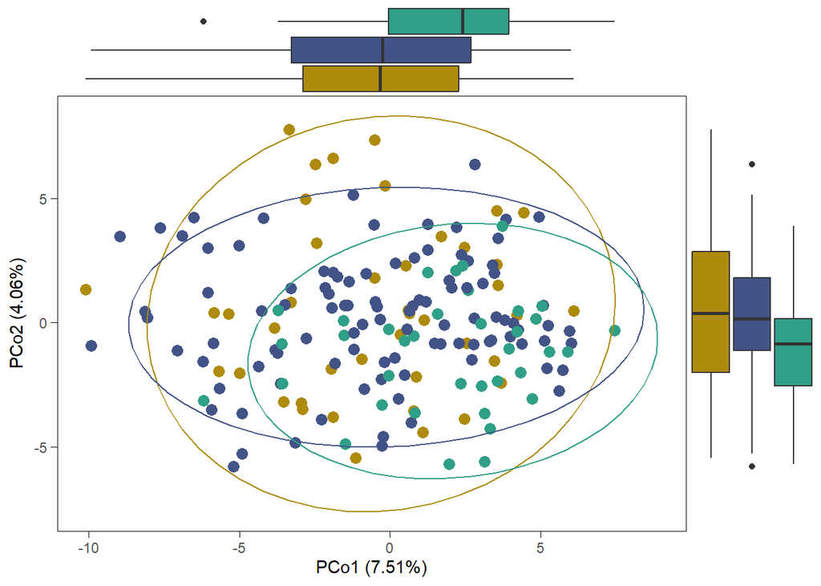

```r
p <- pca_plot_custom(filt_ileum_genus_tab,
                                 filt_ileum_genus_taxa,
                                 filt_ileum_metadata,
                                 show_boxplots = TRUE,
                                 variable = "Group", size=3, show_legend=FALSE)

# save the results
pca_plots_list[[paste(segment,level,"custom")]] <- p

# see the results
p
```

#### 3.3.1.1 Saving results

```r
write.xlsx(pairwise_aitchison_raw[[paste(level, segment)]],
           file = file.path(path,
           paste0("beta_diversity_results_", segment,".xlsx")))
```

## 3.4 Univariate Analysis

Similar to previous approaches, we will use two DAA tools - linDA and Maaslin. Only the intersection of sets selected by each tool are shown to minimize false positives. As this analysis can only be conducted on Czech cohort, no interaction effect can be shown, therefore only Group effect is investigated.

This analysis is performed at genus level only.

```r
level="genus"

# needed paths
path = "../../../results/merged_sites/main_analysis/QALD/univariate_analysis"
path_maaslin=file.path("../../../intermediate_files/maaslin/QALD",level)
```

```r
# variables
raw_linda_results_genus <- list();
raw_linda_results_genus[[segment]] <- list()
linda_results_genus <- list();
linda_results_genus[[segment]] <- list()

# country and interaction problems
list_country_union <- list()
list_intersections <- list()
list_venns <- list()
uni_statistics <- list()

# workbook for final df
wb <- createWorkbook()
```

Aggregate taxa

```r
genus_data <- aggregate_taxa(ileum_asv_tab,
                             ileum_taxa_tab,
                             taxonomic_level = level)

ileum_genus_tab <- genus_data[[1]]
ileum_genus_taxa_tab <- genus_data[[2]]

ileum_genus_asv_taxa_tab <- create_asv_taxa_table(ileum_genus_tab,
                                                  ileum_genus_taxa_tab)
```

### 3.4.1 PSC vs ALD

We can assume, that the differentially abundant taxa between these two groups are caused by PSC disease and other factors, like liver cirrhosis and overall bad clinical condition.

```r
group <- c("ALD post_ltx","PSC post_ltx")
comparison_name <- paste0(group[1], " vs ",group[2])
```

#### 3.4.1.1 linDA

```r
# prepare the data
linda_data <- binomial_prep(ileum_genus_tab,
                            ileum_genus_taxa_tab,
                            ileum_metadata,
                            group, usage="linDA")
```

```
Removing 33 ASV(s)
```

```r
filt_ileum_uni_data <- linda_data[[1]]
filt_ileum_uni_taxa <- linda_data[[2]]
filt_ileum_uni_metadata <- linda_data[[3]]

# fit the model
linda.obj <- linda(filt_ileum_uni_data,
                   filt_ileum_uni_metadata,
                   formula = '~ Group')
```

```
0  features are filtered!
The filtered data has  144  samples and  200  features will be tested!
Pseudo-count approach is used.
Fit linear models ...
Completed.
```

```r
linda.output <- linda.obj$output
linda.output <- linda_renaming(linda.output, group)

# save the results
group1 <- paste0(group[1], " vs ","Group",group[2])

for (grp in c(group1)){
  raw_linda_results_genus[[segment]][[grp]] <-
    rawlinda.df(linda.output,
                grp,
                filt_ileum_uni_data,
                filt_ileum_uni_taxa)

  linda_results_genus[[segment]][[grp]] <-
    linda.df(linda.output,
             grp,
             filt_ileum_uni_data,
             filt_ileum_uni_taxa)
}
```

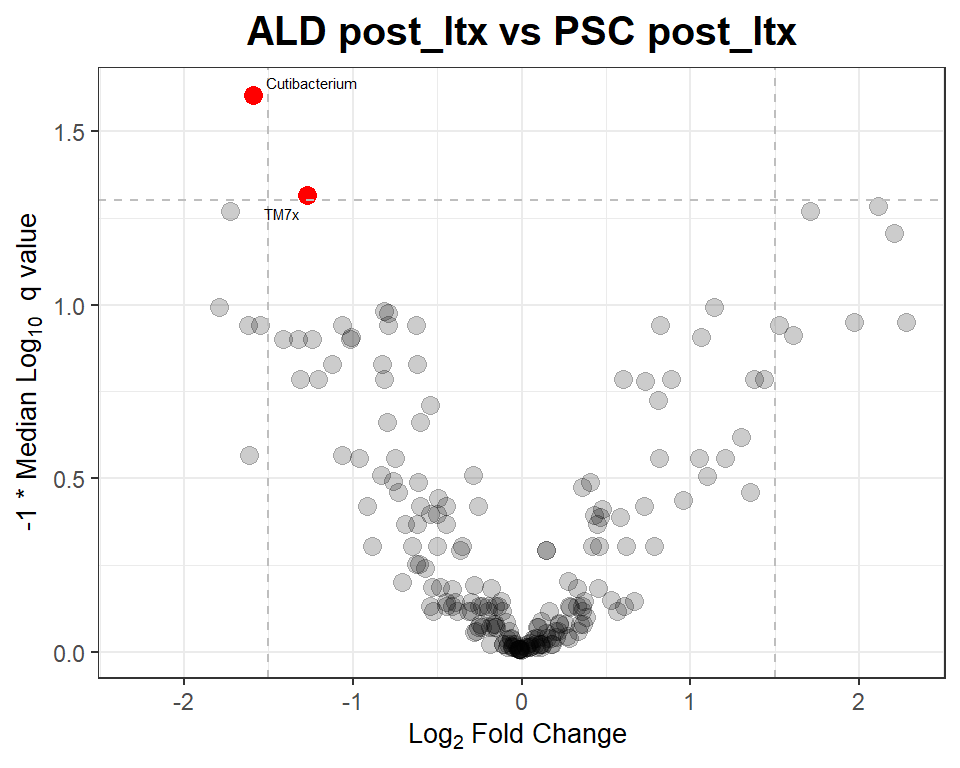

```r
# volcano plots
volcano <- volcano_plot_linda(linda.output,
                                group1,
                                taxa_table = filt_ileum_uni_taxa) +
            ggtitle(comparison_title)

volcano
```

#### 3.4.1.2 MaAsLin2

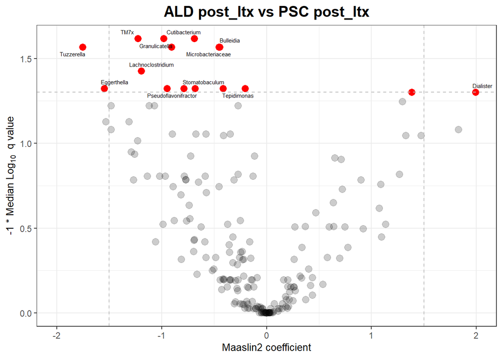

```r
volcano <- volcano_plot_maaslin(fit_data,filt_ileum_uni_taxa) +
            ggtitle(comparison_title)


volcano
```

#### 3.4.1.3 Group - Intersection

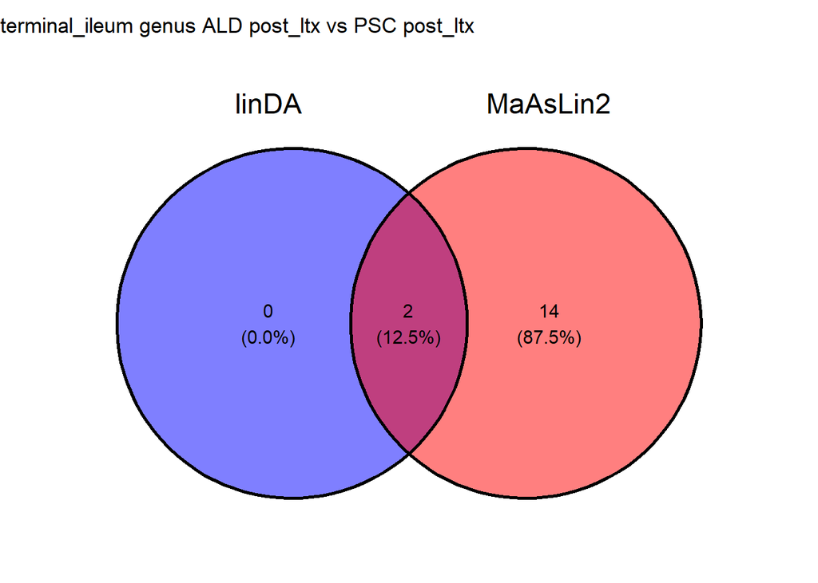

```r
intersection_results <- group_intersection(group, list_intersections, list_venns,
                                           linda.output, fit_data,
                                           raw_linda_results_genus,
                                           segment = segment,
                                           level=level)

list_intersections <- intersection_results[[1]]
list_venns <- intersection_results[[2]]
venn <- intersection_results[[3]]

# show the results
venn
```

#### 3.4.1.4 Basic statistics

```r
uni_df <-  merge(basic_univariate_statistics(linda_data,group),
                 raw_linda_results_genus[[segment]][[group1]],
                 by="SeqID",all=TRUE)
```

```
[1] "ALD post_ltx"
[1] "PSC post_ltx"
[1] "ALD post_ltx"
[1] "PSC post_ltx"
```

```r
uni_df[["final_sig"]] <- uni_df$SeqID %in% list_intersections[[paste(segment,level,comparison_name)]][["SeqID"]]
uni_statistics[[segment]][[paste(level,comparison_name)]] <- uni_df

# for comparison
new_name <- comparison_name
addWorksheet(wb, sheetName = new_name)
writeData(wb, sheet = new_name, uni_df, rowNames=FALSE)
```

#### 3.4.1.5 Comparison with PSC-associated taxa

```r
psc_ald_sig_ti <- uni_df %>%
  dplyr::filter(final_sig==TRUE) %>%
  dplyr::select(SeqID,Taxonomy,log2FoldChange)

psc_genus_ti <- psc_genus_ti
```

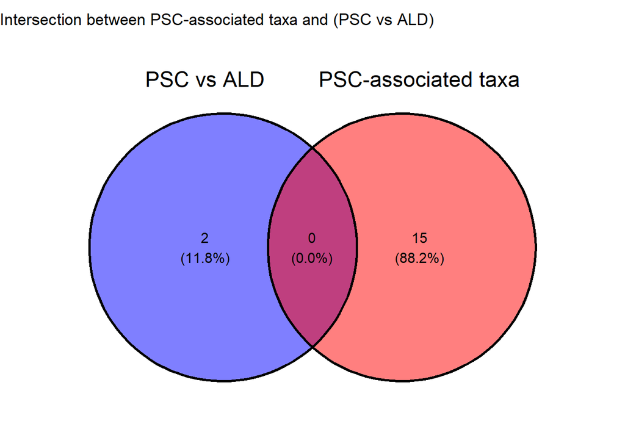

```r
list_core <- list()
list_core[["PSC vs ALD"]] <- psc_ald_sig_ti$Taxonomy
list_core[["PSC-associated taxa"]] <- psc_genus_ti$Taxonomy

# venn diagram
venn <- ggvenn(list_core, fill_color = c("blue", "red")) +
    ggtitle("Intersection between PSC-associated taxa and (PSC vs ALD)") +
    guides(fill = "none")

venn
```

```r
intersection_df <- intersect(list_core$`PSC vs ALD`,list_core$`PSC-associated taxa`)

intersection_df
```

```
character(0)
```

### 3.4.2 ALD vs HC

```r
group <- c("HC","ALD post_ltx")
comparison_name <- paste0(group[1], " vs ",group[2])
```

#### 3.4.2.1 linDA

```r
# prepare the data
linda_data <- binomial_prep(ileum_genus_tab,
                            ileum_genus_taxa_tab,
                            ileum_metadata,
                            group, usage="linDA")
```

```
Removing 82 ASV(s)
```

```r
filt_ileum_uni_data <- linda_data[[1]]
filt_ileum_uni_taxa <- linda_data[[2]]
filt_ileum_uni_metadata <- linda_data[[3]]

# fit the model
linda.obj <- linda(filt_ileum_uni_data,
                   filt_ileum_uni_metadata,
                   formula = '~ Group')
```

```
0  features are filtered!
The filtered data has  79  samples and  216  features will be tested!
```

```
Pseudo-count approach is used.
Fit linear models ...
Completed.
```

```r
linda.output <- linda.obj$output
linda.output <- linda_renaming(linda.output, group)

# save the results
group1 <- paste0(group[1], " vs ","Group",group[2])

for (grp in c(group1)){
  raw_linda_results_genus[[segment]][[grp]] <-
    rawlinda.df(linda.output,
                grp,
                filt_ileum_uni_data,
                filt_ileum_uni_taxa)

  linda_results_genus[[segment]][[grp]] <-
    linda.df(linda.output,
             grp,
             filt_ileum_uni_data,
             filt_ileum_uni_taxa)
}
```

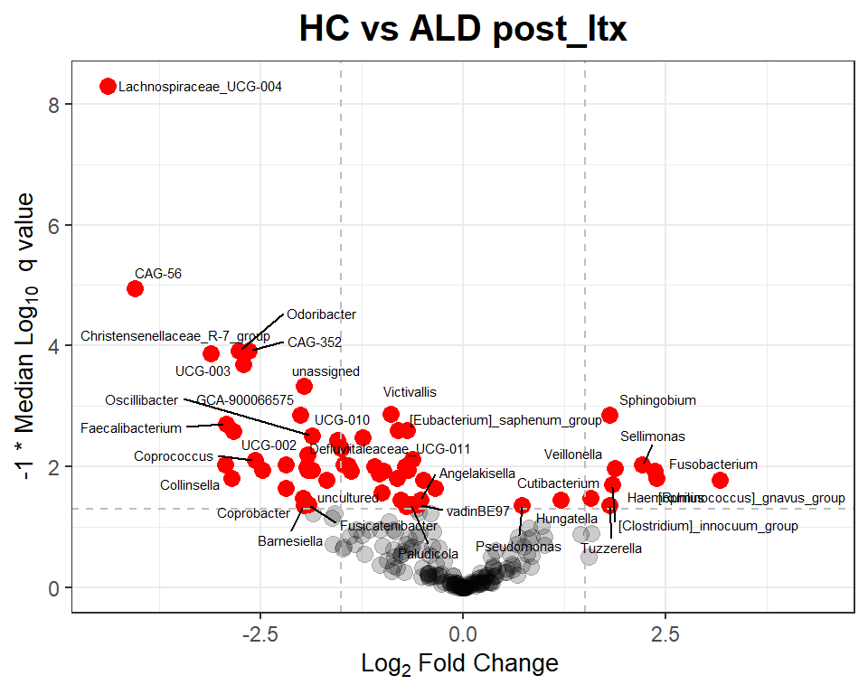

```r
# volcano plots
volcano <- volcano_plot_linda(linda.output,
                                group1,
                                taxa_table = filt_ileum_uni_taxa) +
            ggtitle(comparison_title)

volcano
```

#### 3.4.2.2 MaAsLin2

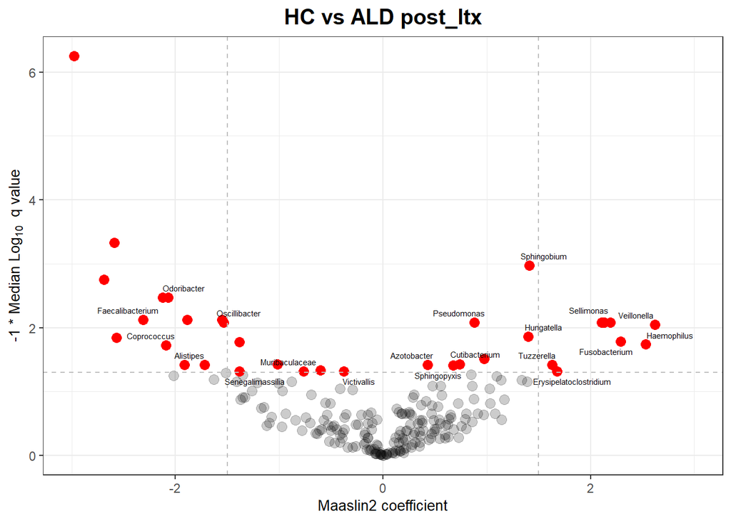

```r
volcano <- volcano_plot_maaslin(fit_data,filt_ileum_uni_taxa) +
            ggtitle(comparison_title)


volcano
```

#### 3.4.2.3 Group - Intersection

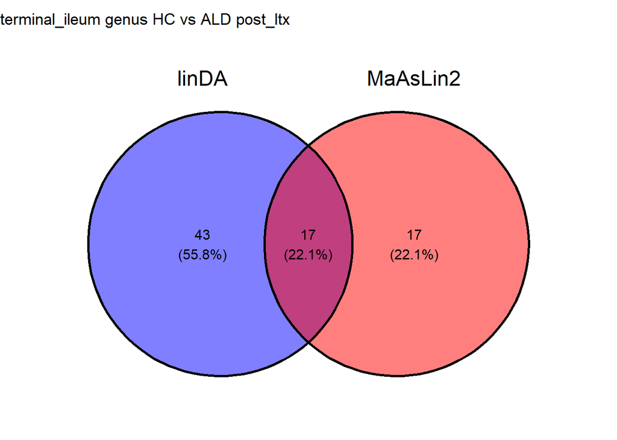

```r
intersection_results <- group_intersection(group, list_intersections, list_venns,
                                           linda.output, fit_data,
                                           raw_linda_results_genus,
                                           segment = segment,
                                           level=level)

list_intersections <- intersection_results[[1]]
list_venns <- intersection_results[[2]]
venn <- intersection_results[[3]]

# show the results
venn
```

#### 3.4.2.4 Basic statistics

```r
uni_df <-  merge(basic_univariate_statistics(linda_data,group),
                 raw_linda_results_genus[[segment]][[group1]],
                 by="SeqID",all=TRUE)
```

```
[1] "HC"
[1] "ALD post_ltx"
[1] "HC"
[1] "ALD post_ltx"
```

```r
uni_df[["final_sig"]] <- uni_df$SeqID %in% list_intersections[[paste(segment,level,comparison_name)]][["SeqID"]]
uni_statistics[[segment]][[paste(level,comparison_name)]] <- uni_df

# for comparison
new_name <- comparison_name
addWorksheet(wb, sheetName = new_name)
writeData(wb, sheet = new_name, uni_df, rowNames=FALSE)
```

#### 3.4.2.5 Comparison with PSC-associated taxa

```r
hc_ald_sig_ti <- uni_df %>%
  dplyr::filter(final_sig==TRUE) %>%
  dplyr::select(SeqID,Taxonomy,log2FoldChange)

psc_genus_ti <- psc_genus_ti
```

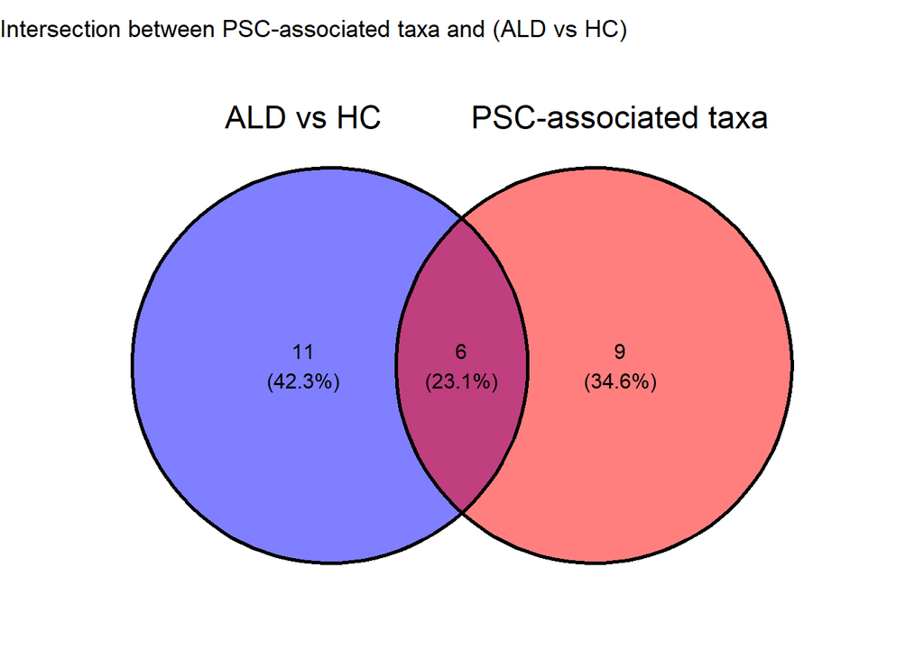

```r
list_core <- list()
list_core[["ALD vs HC"]] <- hc_ald_sig_ti$Taxonomy
list_core[["PSC-associated taxa"]] <- psc_genus_ti$Taxonomy

# venn diagram
venn <- ggvenn(list_core, fill_color = c("blue", "red")) +
    ggtitle("Intersection between PSC-associated taxa and (ALD vs HC)") +
    guides(fill = "none")

venn
```

From this Venn diagram, we are interested in EXLUSIVE RIGH JOIN

```r
A <- list_core$`ALD vs HC`
B <- list_core$`PSC-associated taxa`
remaining_psc <- B[!(B %in% A)]

psc_genus_ti %>%
  dplyr::filter(Taxonomy %in% remaining_psc)
```

```
                         SeqID
1                Enterorhabdus
2                  Barnesiella
3                Butyricimonas
4              Parabacteroides
5                   Holdemania
6             Fusicatenibacter
7            Lachnoclostridium
8 Lachnospiraceae_FCS020_group
9                 Enterococcus
                                                                                                      Taxonomy
1    k__Bacteria;p__Actinobacteriota;c__Coriobacteriia;o__Coriobacteriales;f__Eggerthellaceae;g__Enterorhabdus
2                k__Bacteria;p__Bacteroidota;c__Bacteroidia;o__Bacteroidales;f__Barnesiellaceae;g__Barnesiella
3               k__Bacteria;p__Bacteroidota;c__Bacteroidia;o__Bacteroidales;f__Marinifilaceae;g__Butyricimonas
4             k__Bacteria;p__Bacteroidota;c__Bacteroidia;o__Bacteroidales;f__Tannerellaceae;g__Parabacteroides
5              k__Bacteria;p__Firmicutes;c__Bacilli;o__Erysipelotrichales;f__Erysipelotrichaceae;g__Holdemania
6             k__Bacteria;p__Firmicutes;c__Clostridia;o__Lachnospirales;f__Lachnospiraceae;g__Fusicatenibacter
7            k__Bacteria;p__Firmicutes;c__Clostridia;o__Lachnospirales;f__Lachnospiraceae;g__Lachnoclostridium
8 k__Bacteria;p__Firmicutes;c__Clostridia;o__Lachnospirales;f__Lachnospiraceae;g__Lachnospiraceae_FCS020_group
9                   k__Bacteria;p__Firmicutes;c__Bacilli;o__Lactobacillales;f__Enterococcaceae;g__Enterococcus
  log2FoldChange      p_value         padj
1      -1.050549 1.087023e-02 4.545734e-02
2      -3.177161 1.263665e-03 7.750481e-03
3      -2.900425 6.571752e-05 9.301556e-04
4      -3.418185 1.366753e-05 2.794251e-04
5      -1.213660 1.082333e-02 4.545734e-02
6      -2.864295 5.224510e-04 4.336862e-03
7      -1.781011 1.555333e-03 9.231654e-03
8      -2.231945 8.971276e-04 6.113758e-03
9       4.892498 4.554602e-10 8.380467e-08
```

```r
uni_df %>%
  dplyr::filter(Taxonomy %in% remaining_psc)
```

```
                         SeqID  Q1_clr HC Q1_clr ALD post_ltx     Q1_ra HC
1                  Barnesiella  2.2306841           -1.154492 0.0008978388
2                Butyricimonas  0.4732196           -1.336010 0.0001128859
3                 Enterococcus -1.8330261           -1.727812 0.0000000000
4                Enterorhabdus -1.5823853           -1.727812 0.0000000000
5             Fusicatenibacter  2.4909696           -0.227097 0.0015781761
6                   Holdemania -1.5163636           -1.717373 0.0000000000
7            Lachnoclostridium  4.5353883            4.487578 0.0166991131
8 Lachnospiraceae_FCS020_group  0.3961494           -1.526367 0.0001974724
9              Parabacteroides  3.4409794            0.750685 0.0033754974
  Q1_ra ALD post_ltx MEDIAN_clr HC MEDIAN_clr ALD post_ltx MEDIAN_clr_ALL
1       0.0000000000      3.390671               2.2487867      3.0290037
2       0.0000000000      1.642021               0.3369299      1.1642191
3       0.0000000000     -1.582385              -1.3920182     -1.5512393
4       0.0000000000     -1.233676              -1.3572043     -1.3225254
```

[output cut: 75 more lines]

#### 3.4.2.6 Visualization

Heatmap visualizing the linDA’s logFoldChange for taxa with p < 0.1.

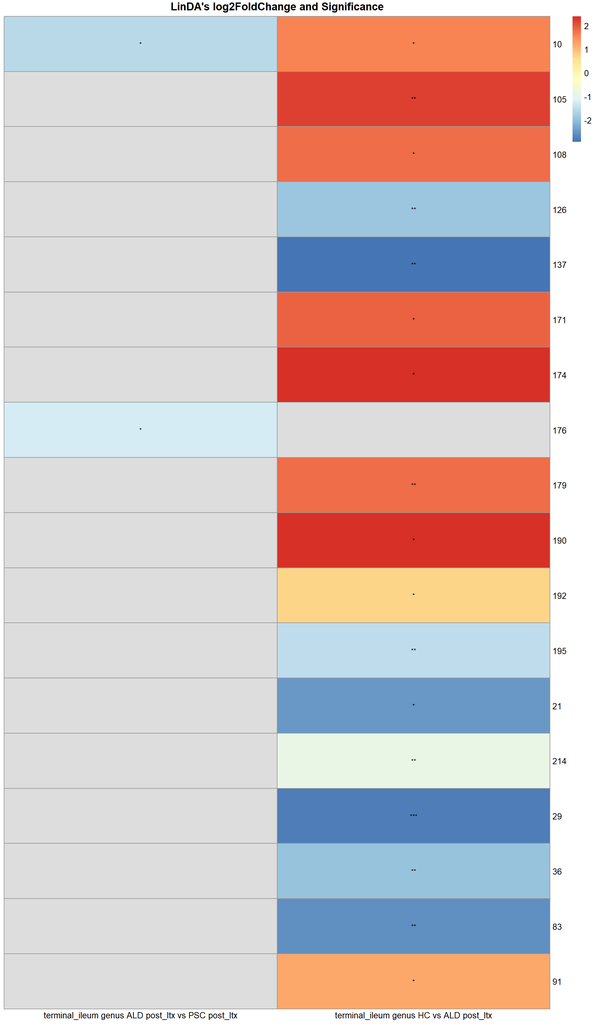

```r
list_heatmap <- list_intersections[grep(paste(segment,level),
                                  names(list_intersections),value=TRUE)]

p_heatmap_linda <- heatmap_linda(list_heatmap,ileum_taxa_tab)
p_heatmap_linda
```

**Dot heatmap**

```r
dotheatmap_linda <- dot_heatmap_linda(list_heatmap,
                                      uni_statistics$terminal_ileum[grepl(level,names(uni_statistics$terminal_ileum))],
                                      ileum_taxa_tab) + xlab("") + ylab("")
```

```
min_clr -1.551239
max_clr 6.219872
min_log -2.921954
max_log 2.390885
```

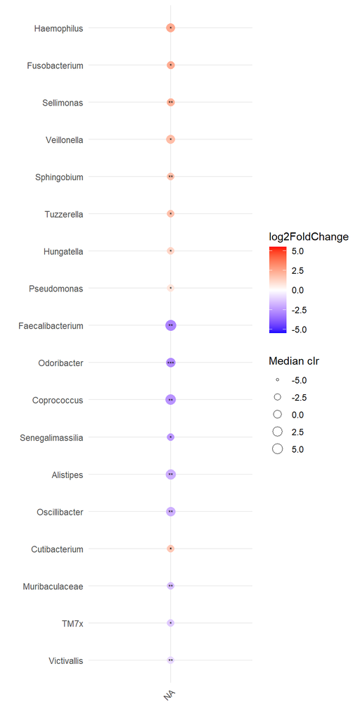

```r
dotheatmap_linda
```

**Horizontal bar plot**

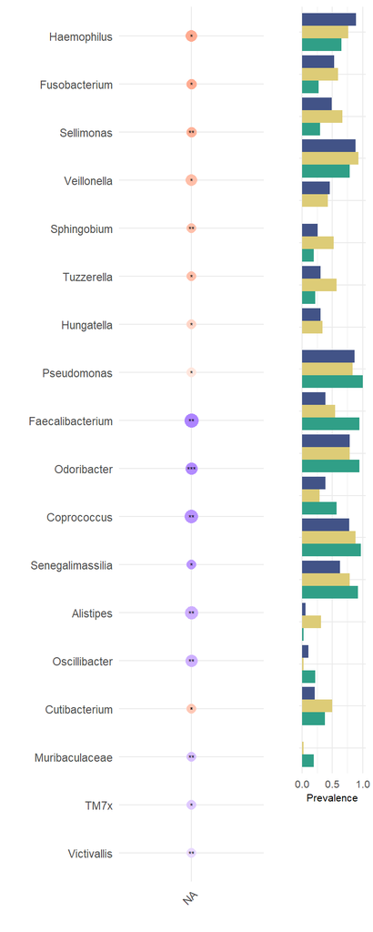

```r
p_prevalence <- horizontal_barplot(wb,taxa=levels(dotheatmap_linda$data$SeqID))
p_prevalence_final <- ggarrange(p_prevalence,
                                ggplot() + theme_minimal(),
                                nrow = 2,heights = c(1,0.15))
p <- ggarrange(dotheatmap_linda + theme(legend.position = "none"),
               p_prevalence_final,
               ncol=2,widths = c(0.8,0.3))
p
```

```r
dot_heatmap_ileum <- p
```

# 4 Data Analysis - Colon

```r
segment="colon"

colon_data <- merging_data(asv_tab_1=asv_tab_ALD,
                           asv_tab_2=asv_tab_ikem,
                           taxa_tab_1=taxa_tab_ALD,
                           taxa_tab_2=taxa_tab_ikem,
                           metadata_1=metadata_ALD,
                           metadata_2=metadata_ikem,
                           segment=segment,Q="QALD")
```

```
Removing 158 ASV(s)
```

```
Removing 739 ASV(s)
```

```
Merging at ASV level
```

```
Finding inconsistencies in taxonomy, trying to keep the ones that have better taxonomy assignment
```

```
Removing 207 ASV(s)
```

```r
colon_asv_tab <- colon_data[[1]]
colon_taxa_tab <- colon_data[[2]]
colon_metadata <- colon_data[[3]]
```

## 4.1 Filtering

Rules: - sequencing depth > 10000 - nearZeroVar() with default settings

Library size

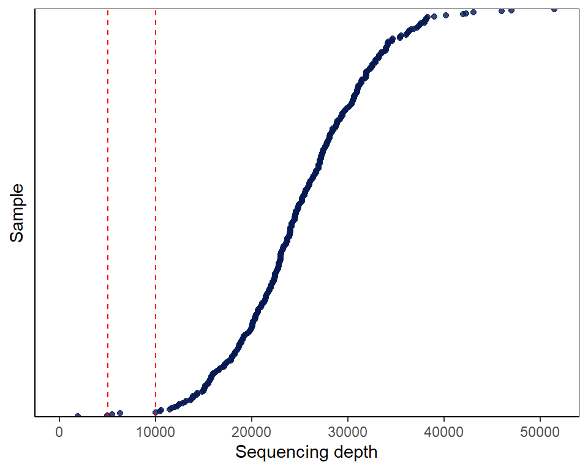

```r
read_counts(colon_asv_tab, line = c(5000,10000))
```

### 4.1.1 Sequencing depth

```r
data_filt <- seq_depth_filtering(colon_asv_tab,
                                 colon_taxa_tab,
                                 colon_metadata,
                                 seq_depth_threshold = 10000)
```

```
Removing 4 ASV(s)
```

```r
filt_colon_asv_tab <- data_filt[[1]]; alpha_colon_asv_tab <- filt_colon_asv_tab
filt_colon_taxa_tab <- data_filt[[2]]; alpha_colon_taxa_tab <- filt_colon_taxa_tab
filt_colon_metadata <- data_filt[[3]]; alpha_colon_metadata <- filt_colon_metadata

seq_step <- dim(filt_colon_asv_tab)[1]
```

Library size

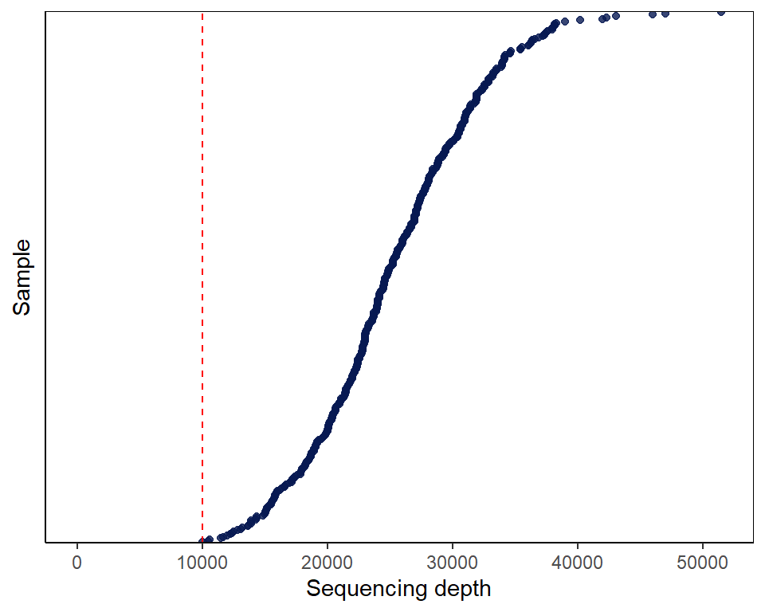

```r
read_counts(filt_colon_asv_tab,line = c(10000))
```

### 4.1.2 NearZeroVar

```r
data_filt <- nearzerovar_filtering(filt_colon_asv_tab,
                                   filt_colon_taxa_tab,
                                   filt_colon_metadata)

filt_colon_asv_tab <- data_filt[[1]]
filt_colon_taxa_tab <- data_filt[[2]]
nearzero_step <- dim(filt_colon_asv_tab)[1]
```

Library size

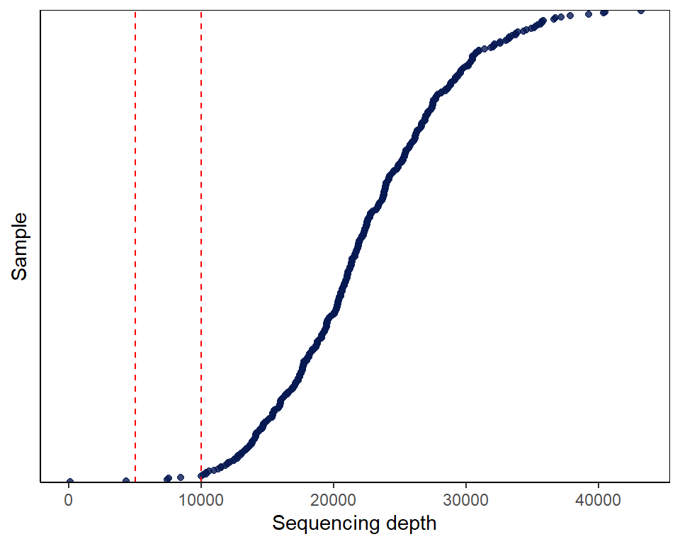

```r
read_counts(filt_colon_asv_tab,line = c(5000,10000))
```

Check zero depth

```r
data_filt <- check_zero_depth(filt_colon_asv_tab,
                              filt_colon_taxa_tab,
                              filt_colon_metadata)

filt_colon_asv_tab <- data_filt[[1]];
filt_colon_taxa_tab <- data_filt[[2]];
filt_colon_metadata <- data_filt[[3]];
```

Library size

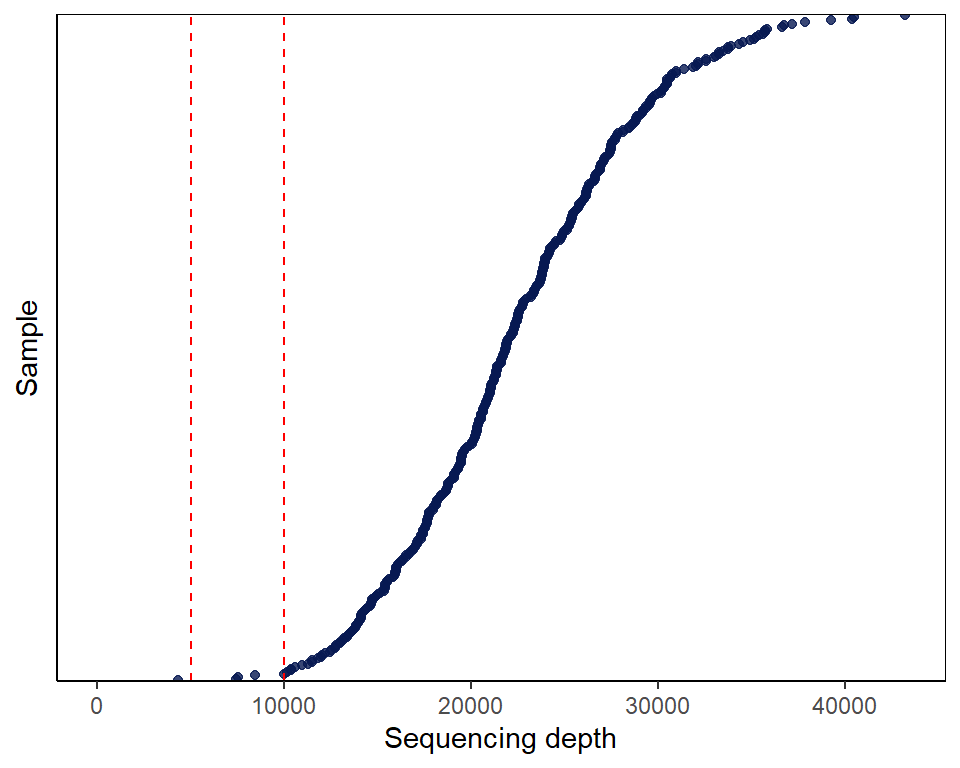

```r
read_counts(filt_colon_asv_tab,line = c(5000,10000))
```

### 4.1.3 Final Counts

```r
final_counts_filtering(colon_asv_tab,
                       filt_colon_asv_tab,
                       filt_colon_metadata,
                       seq_step, 0, nearzero_step)
```

```
                                         V1
Raw data: ASVs                         4893
Raw data: Samples                       400
Sequencing depth filt: ASVs            4889
Prevalence filt: ASVs                     0
NearZeroVar filt: ASVs                  514
Filt data: ASVs                         514
Filt data: Samples                      395
Filt data: Patients                     210
Filt data: Patients.1                     0
Filtered samples                          5
Matrices                    Cecum;Rectum;CD
healthy                                   0
non-rPSC                                  0
rPSC                                      0
pre_ltx                                   0
post_ltx                                  0
ETOH                                      0
```

## 4.2 Alpha diversity

Calculating Richness, Shannon, Simpson, Pielou indexes on raw (unfiltered) rarefied data. Samples with sequencing depth < 10000 were excluded. Testing by linear mixed-effect model.

```r
path = "../../../results/merged_sites/main_analysis/QALD/alpha_diversity"
```

**Calculation**

```r
# Construct MPSE object
alpha_colon_metadata$Sample <- alpha_colon_metadata$SampleID
colon_mpse <- as.MPSE(construct_phyloseq(alpha_colon_asv_tab,
                                         alpha_colon_taxa_tab,
                                         alpha_colon_metadata))

colon_mpse %<>% mp_rrarefy(raresize = 10000,seed = 123)

# Calculate alpha diversity - rarefied counts
colon_mpse %<>% mp_cal_alpha(.abundance=RareAbundance, force=TRUE)
```

```r
alpha_data <- data.frame(SampleID=colon_mpse$Sample.x,
                         Observe=colon_mpse$Observe,
                         Shannon=colon_mpse$Shannon,
                         Simpson=colon_mpse$Simpson,
                         Pielou=colon_mpse$Pielou,
                         Group=colon_mpse$Group,
                         Country=colon_mpse$Country,
                         Patient=colon_mpse$Patient)

write.csv(alpha_data,file.path(path,paste0("alpha_indices_",segment,".csv")),
          row.names = FALSE)
```

### 4.2.1 Plots

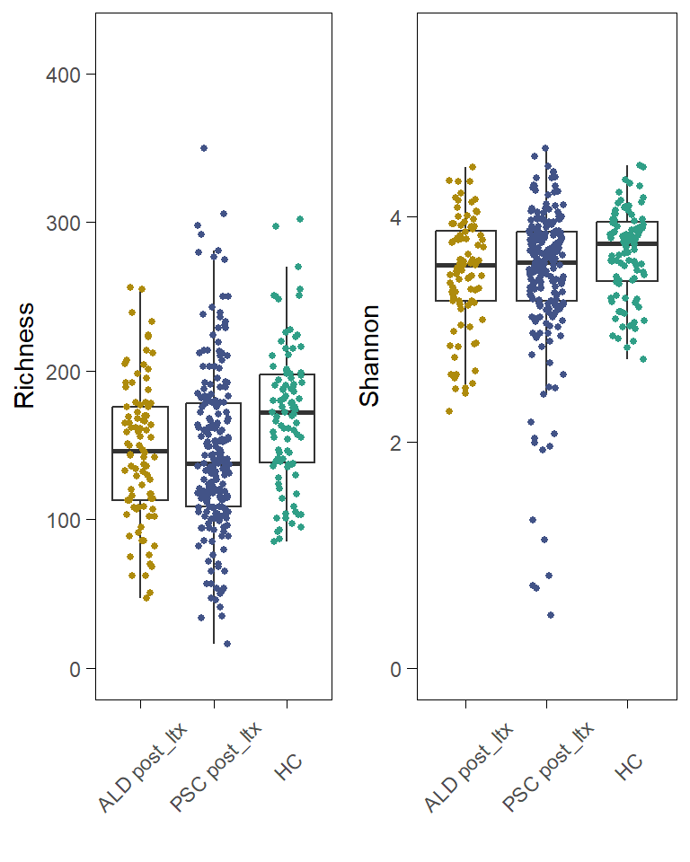

```r
p_boxplot_alpha <- alpha_diversity_countries(alpha_data,
                                             show_legend = FALSE,
                                             size=1,gap=TRUE,jitter = 1.5)
# save the results
alpha_div_plots[[paste(segment,"Country")]] <- p_boxplot_alpha

# see the results
p_boxplot_alpha
```

### 4.2.2 Linear Model

```r
path = "../../../results/merged_sites/main_analysis/QALD/alpha_diversity"
alpha_data <- read.csv(file.path(path,paste0("alpha_indices_",segment,".csv")))
```

**Richness**

```r
results_model <- pairwise.lmer(
  formula = "Observe ~ Group + (1|Patient)",
  factors=alpha_data$Group,
  data=alpha_data)

# check interaction
if (!is.data.frame(results_model)){
  results_model_observe <- results_model[[1]]
  results_model_observe_detailed <- results_model[[2]]
} else {
  results_model_observe <- results_model
  results_model_observe_detailed <- NA
}

# save the results
pc_observed[[segment]] <- results_model_observe
```

```r
# see the results
knitr::kable(results_model_observe,digits = 3,
caption = "Raw results of linear model of richness estimation.")
```

Raw results of linear model of richness estimation.

|  | Estimate | Std..Error | df | t.value | Pr…t.. | p.adj | sig |
| --- | --- | --- | --- | --- | --- | --- | --- |
| HC vs GroupALD post_ltx | -25.783 | 8.899 | 101.256 | -2.897 | 0.005 | 0.007 | ** |
| ALD post_ltx vs GroupPSC post_ltx | -1.333 | 8.824 | 154.989 | -0.151 | 0.880 | 0.880 |  |
| HC vs GroupPSC post_ltx | -27.170 | 8.556 | 161.321 | -3.175 | 0.002 | 0.005 | ** |

```r
knitr::kable(results_model_observe_detailed,digits = 3,
caption = "Raw results of independent country analysis")
```

**Shannon**

```r
results_model <- pairwise.lmer(
  formula = "Shannon ~ Group  + (1|Patient)",
  factors=alpha_data$Group,
  data=alpha_data)

# check interaction
if (!is.data.frame(results_model)){
  results_model_shannon <- results_model[[1]]
  results_model_shannon_detailed <- results_model[[2]]
} else {
  results_model_shannon <- results_model
  results_model_shannon_detailed <- NA
}

# save the results
pc_shannon[[segment]] <- as.data.frame(results_model_shannon)
```

```r
# see the results
knitr::kable(results_model_shannon,digits = 3,
caption = "Raw results of linear model of Shannon estimation.")
```

Raw results of linear model of Shannon estimation.

|  | Estimate | Std..Error | df | t.value | Pr…t.. | p.adj | sig |
| --- | --- | --- | --- | --- | --- | --- | --- |
| HC vs GroupALD post_ltx | -0.187 | 0.083 | 101.292 | -2.251 | 0.027 | 0.047 | * |
| ALD post_ltx vs GroupPSC post_ltx | -0.028 | 0.108 | 152.383 | -0.257 | 0.797 | 0.797 |  |
| HC vs GroupPSC post_ltx | -0.218 | 0.100 | 158.220 | -2.172 | 0.031 | 0.047 | * |

```r
knitr::kable(results_model_shannon_detailed,digits = 3,
caption = "Raw results of independent country analysis")
```

**Simpson**

```r
results_model <- pairwise.lmer(
  formula = "Simpson ~ Group + (1|Patient)",
  factors=alpha_data$Group,
  data=alpha_data)

# check interaction
if (!is.data.frame(results_model)){
  results_model_simpson <- results_model[[1]]
  results_model_simpson_detailed <- results_model[[2]]
} else {
  results_model_simpson <- results_model
  results_model_simpson_detailed <- NA
}

# save the results
pc_simpson[[segment]] <- as.data.frame(results_model_simpson)
```

```r
# see the results
knitr::kable(results_model_simpson,digits = 3,
caption = "Raw results of linear model of Simpson estimation.")
```

Raw results of linear model of Simpson estimation.

|  | Estimate | Std..Error | df | t.value | Pr…t.. | p.adj | sig |
| --- | --- | --- | --- | --- | --- | --- | --- |
| HC vs GroupALD post_ltx | -0.007 | 0.006 | 100.855 | -1.206 | 0.231 | 0.284 |  |
| ALD post_ltx vs GroupPSC post_ltx | -0.019 | 0.018 | 152.512 | -1.074 | 0.284 | 0.284 |  |
| HC vs GroupPSC post_ltx | -0.027 | 0.017 | 157.717 | -1.607 | 0.110 | 0.284 |  |

```r
knitr::kable(results_model_simpson_detailed,digits = 3,
caption = "Raw results of independent country analysis")
```

**Pielou**

```r
results_model <- pairwise.lmer(
  formula = "Pielou ~ Group + (1|Patient)",
  factors=alpha_data$Group,
  data=alpha_data)

# check interaction
if (!is.data.frame(results_model)){
  results_model_pielou <- results_model[[1]]
  results_model_pielou_detailed <- results_model[[2]]
} else {
  results_model_pielou <- results_model
  results_model_pielou_detailed <- NA
}

# save the results
pc_pielou[[segment]] <- as.data.frame(results_model_pielou)
```

```r
# see the results
knitr::kable(results_model_pielou,digits = 3,
caption = "Raw results of linear model of Pielou estimation.")
```

Raw results of linear model of Pielou estimation.

|  | Estimate | Std..Error | df | t.value | Pr…t.. | p.adj | sig |
| --- | --- | --- | --- | --- | --- | --- | --- |
| HC vs GroupALD post_ltx | -0.013 | 0.011 | 101.108 | -1.182 | 0.240 | 0.401 |  |
| ALD post_ltx vs GroupPSC post_ltx | -0.004 | 0.017 | 151.723 | -0.244 | 0.807 | 0.807 |  |
| HC vs GroupPSC post_ltx | -0.018 | 0.016 | 157.456 | -1.113 | 0.267 | 0.401 |  |

```r
knitr::kable(results_model_pielou_detailed,digits = 3,
caption = "Raw results of independent country analysis")
```

### 4.2.3 Saving results

```r
alpha_list <- list(
  Richness=pc_observed[[segment]] %>% rownames_to_column("Comparison"),
  Shannon=pc_shannon[[segment]] %>% rownames_to_column("Comparison"),
  Simpson=pc_simpson[[segment]] %>% rownames_to_column("Comparison"),
  Pielou=pc_pielou[[segment]] %>% rownames_to_column("Comparison"))

write.xlsx(alpha_list,
           file = file.path(path,paste0("alpha_diversity_results_",segment,".xlsx")))
```

## 4.3 Beta diversity

Calculating Aitchison distance (euclidean distance on clr-transformed data) at genus level (main analysis). In supplements, there are also bray-curtis and Jaccard distance at ASV and genus levels. Testing by PERMANOVA.

### 4.3.1 Main analysis

**Genus level, Aitchison distance**

```r
level="genus"
```

```r
path = "../../../results/merged_sites/main_analysis/QALD/beta_diversity"
```

Aggregation, filtering

```r
genus_data <- aggregate_taxa(colon_asv_tab,
                             colon_taxa_tab,
                             taxonomic_level=level,
                             names=TRUE)

filt_data <- filtering_steps(genus_data[[1]],
                             genus_data[[2]],
                             colon_metadata,
                            seq_depth_threshold=10000)

filt_colon_genus_tab <- filt_data[[1]]
filt_colon_genus_taxa <- filt_data[[2]]
filt_colon_genus_metadata <- filt_data[[3]]
```

### 4.3.2 PERMANOVA

```r
pairwise_df <- filt_colon_genus_tab %>% column_to_rownames("SeqID") %>% t()

# main effect
pp_main <- pairwise.adonis(pairwise_df,filt_colon_genus_metadata$Group,
                           patients = filt_colon_genus_metadata$Patient,
                           sim.method = "robust.aitchison", p.adjust.m="BH")


# tidy the results
pp_factor <- pp_main

cols <- c("pairs","Df","SumsOfSqs", "F.Model","R2","p.value", "p.adjusted", "sig")
colnames(pp_factor) <- cols

# save raw results
pairwise_aitchison_raw[[paste(level, segment)]] <-rbind(pp_factor
                                                        )
```

```r
# see the results
knitr::kable(pp_factor,digits = 3,caption = "PERMANOVA, GROUP separation")
```

PERMANOVA, GROUP separation

| pairs | Df | SumsOfSqs | F.Model | R2 | p.value | p.adjusted | sig |
| --- | --- | --- | --- | --- | --- | --- | --- |
| HC vs ALD post_ltx | 1 | 912.451 | 5.183 | 0.027 | 0.001 | 0.002 | ** |
| ALD post_ltx vs PSC post_ltx | 1 | 477.932 | 2.675 | 0.009 | 0.040 | 0.040 | * |
| HC vs PSC post_ltx | 1 | 1115.245 | 6.365 | 0.021 | 0.001 | 0.002 | ** |

##### 4.3.2.0.1 Plots

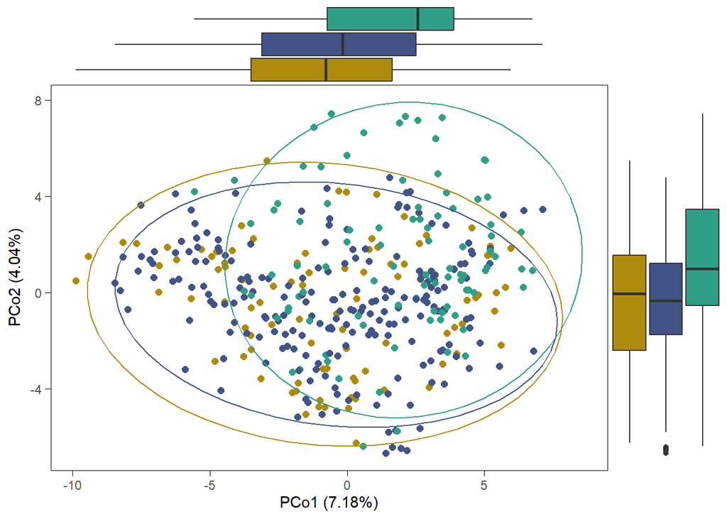

```r
p <- pca_plot_custom(filt_colon_genus_tab,
                                 filt_colon_genus_taxa,
                                 filt_colon_genus_metadata,
                                 show_boxplots = TRUE,
                                 variable = "Group", size=2,
                                 show_legend= FALSE)

# save the results
pca_plots_list[[paste(segment,level,"custom")]] <- p

# see the results
p
```

#### 4.3.2.1 Saving results

```r
write.xlsx(pairwise_aitchison_raw[[paste(level, segment)]],
           file = file.path(path,
           paste0("beta_diversity_results_", segment,".xlsx")))
```

## 4.4 Univariate Analysis

```r
level="genus"
```

```r
# needed paths
path = "../../../results/merged_sites/main_analysis/QALD/univariate_analysis"
path_maaslin=file.path("../../../intermediate_files/maaslin/QALD",level)

# variables
raw_linda_results_genus[[segment]] <- list()
linda_results_genus[[segment]] <- list()

# country and interaction problems
list_country_union <- list()
list_venns <- list()

# workbook for final df
wb <- createWorkbook()
```

```r
level="genus"
```

Aggregate taxa

```r
genus_data <- aggregate_taxa(colon_asv_tab,
                             colon_taxa_tab,
                             taxonomic_level = level)

colon_genus_tab <- genus_data[[1]]
colon_genus_taxa_tab <- genus_data[[2]]

colon_genus_asv_taxa_tab <- create_asv_taxa_table(colon_genus_tab,
                                                  colon_genus_taxa_tab)
```

##### 4.4.0.0.1 PSC vs ALD

###### 4.4.0.0.1.1 linDA

```r
group <- c("ALD post_ltx","PSC post_ltx")
comparison_name <- paste0(group[1], " vs ",group[2])
```

```r
# prepare the data
linda_data <- binomial_prep(colon_genus_tab,
                            colon_genus_taxa_tab,
                            colon_metadata,
                            group, usage="linDA")
```

```
Removing 12 ASV(s)
```

```r
filt_colon_uni_data <- linda_data[[1]]
filt_colon_uni_taxa <- linda_data[[2]]
filt_colon_uni_metadata <- linda_data[[3]]

# fit the model
linda.obj <- linda(filt_colon_uni_data,
                   filt_colon_uni_metadata,
                   formula = '~ Group + (1|Patient)')
```

```
0  features are filtered!
The filtered data has  301  samples and  170  features will be tested!
Imputation approach is used.
Fit linear mixed effects models ...
Completed.
```

```r
linda.output <- linda.obj$output
linda.output <- linda_renaming(linda.output, group)

# save the results
group1 <- paste0(group[1], " vs ","Group",group[2])

for (grp in c(group1)){
  raw_linda_results_genus[[segment]][[grp]] <-
    rawlinda.df(linda.output,
                grp,
                filt_colon_uni_data,
                filt_colon_uni_taxa)

  linda_results_genus[[segment]][[grp]] <-
    linda.df(linda.output,
             grp,
             filt_colon_uni_data,
             filt_colon_uni_taxa)
}
```

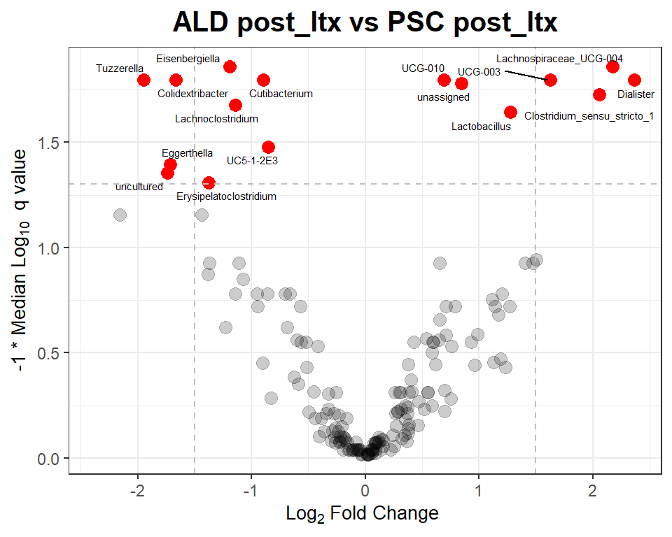

```r
# volcano plot
volcano <- volcano_plot_linda(linda.output, group1,
                                taxa_table = filt_colon_uni_taxa) +
            ggtitle(paste(group,collapse=" vs "))


# see the plot
volcano
```

###### 4.4.0.0.1.2 MaAsLin2

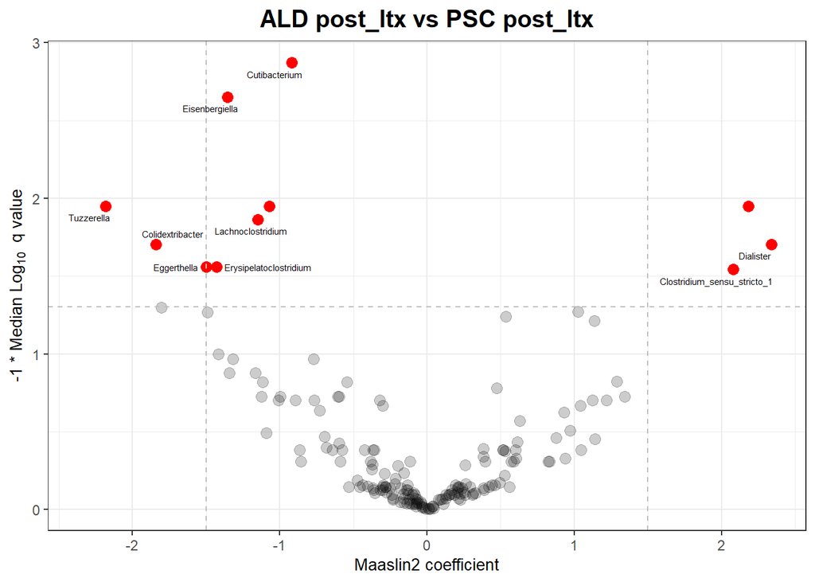

```r
volcano <- volcano_plot_maaslin(fit_data,filt_colon_uni_taxa) +
            ggtitle(paste(group[1], "vs", group[2]))

volcano
```

###### 4.4.0.0.1.3 Group - Intersection

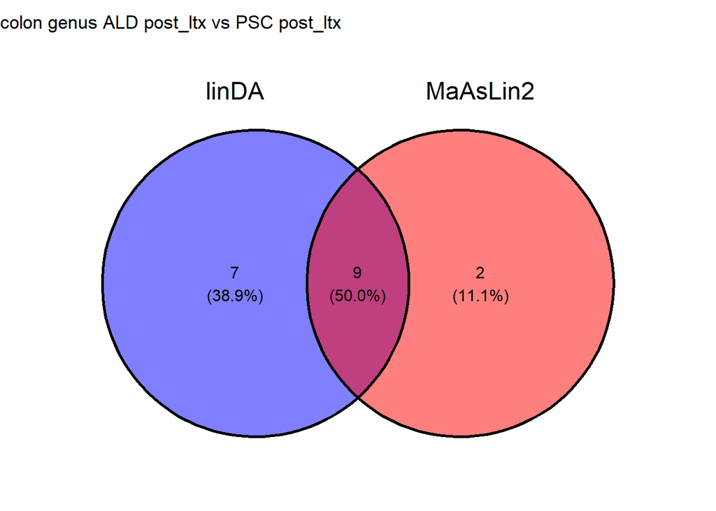

```r
intersection_results <- group_intersection(group, list_intersections, list_venns,
                                           linda.output, fit_data,
                                           raw_linda_results_genus,
                                           segment = segment,
                                           level=level)

list_intersections <- intersection_results[[1]]
list_venns <- intersection_results[[2]]
venn <- intersection_results[[3]]

# show the results
venn
```

###### 4.4.0.0.1.4 Basic statistics

```r
uni_df <-  merge(basic_univariate_statistics(linda_data,group),
                 raw_linda_results_genus[[segment]][[group1]],
                 by="SeqID",all=TRUE)
```

```
[1] "ALD post_ltx"
[1] "PSC post_ltx"
[1] "ALD post_ltx"
[1] "PSC post_ltx"
```

```r
uni_df[["final_sig"]] <- uni_df$SeqID %in% list_intersections[[paste(segment,level,comparison_name)]][["SeqID"]]
uni_statistics[[segment]][[paste(level,comparison_name)]] <- uni_df

# for comparison
new_name <- comparison_name
addWorksheet(wb, sheetName = new_name)
writeData(wb, sheet = new_name, uni_df, rowNames=FALSE)
```

###### 4.4.0.0.1.5 Comparison with PSC-associated taxa

```r
psc_ald_sig_colon <- uni_df %>%
  dplyr::filter(final_sig==TRUE) %>%
  dplyr::select(SeqID,Taxonomy,log2FoldChange)

psc_genus_colon <- psc_genus_colon
```

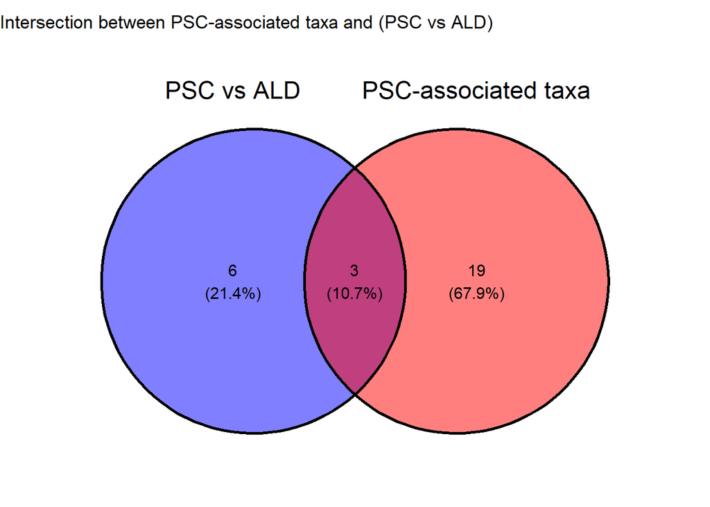

```r
list_core <- list()
list_core[["PSC vs ALD"]] <- psc_ald_sig_colon$Taxonomy
list_core[["PSC-associated taxa"]] <- psc_genus_colon$Taxonomy

# venn diagram
venn <- ggvenn(list_core, fill_color = c("blue", "red")) +
    ggtitle("Intersection between PSC-associated taxa and (PSC vs ALD)") +
    guides(fill = "none")

venn
```

```r
intersection_df <- intersect(list_core$`PSC vs ALD`,list_core$`PSC-associated taxa`)

intersection_df
```

```
[1] "k__Bacteria;p__Firmicutes;c__Clostridia;o__Oscillospirales;f__Oscillospiraceae;g__Colidextribacter"
[2] "k__Bacteria;p__Firmicutes;c__Negativicutes;o__Veillonellales-Selenomonadales;f__Veillonellaceae;g__Dialister"
[3] "k__Bacteria;p__Firmicutes;c__Clostridia;o__Lachnospirales;f__Lachnospiraceae;g__Lachnoclostridium"
```

##### 4.4.0.0.2 ALD vs HC

###### 4.4.0.0.2.1 linDA

```r
group <- c("HC","ALD post_ltx")
comparison_name <- paste0(group[1], " vs ",group[2])
```

```r
# prepare the data
linda_data <- binomial_prep(colon_genus_tab,
                            colon_genus_taxa_tab,
                            colon_metadata,
                            group, usage="linDA")
```

```
Removing 100 ASV(s)
```

```r
filt_colon_uni_data <- linda_data[[1]]
filt_colon_uni_taxa <- linda_data[[2]]
filt_colon_uni_metadata <- linda_data[[3]]

# fit the model
linda.obj <- linda(filt_colon_uni_data,
                   filt_colon_uni_metadata,
                   formula = '~ Group + (1|Patient)')
```

```
0  features are filtered!
The filtered data has  187  samples and  186  features will be tested!
Imputation approach is used.
Fit linear mixed effects models ...
Completed.
```

```r
linda.output <- linda.obj$output
linda.output <- linda_renaming(linda.output, group)

# save the results
group1 <- paste0(group[1], " vs ","Group",group[2])

for (grp in c(group1)){
  raw_linda_results_genus[[segment]][[grp]] <-
    rawlinda.df(linda.output,
                grp,
                filt_colon_uni_data,
                filt_colon_uni_taxa)

  linda_results_genus[[segment]][[grp]] <-
    linda.df(linda.output,
             grp,
             filt_colon_uni_data,
             filt_colon_uni_taxa)
}
```

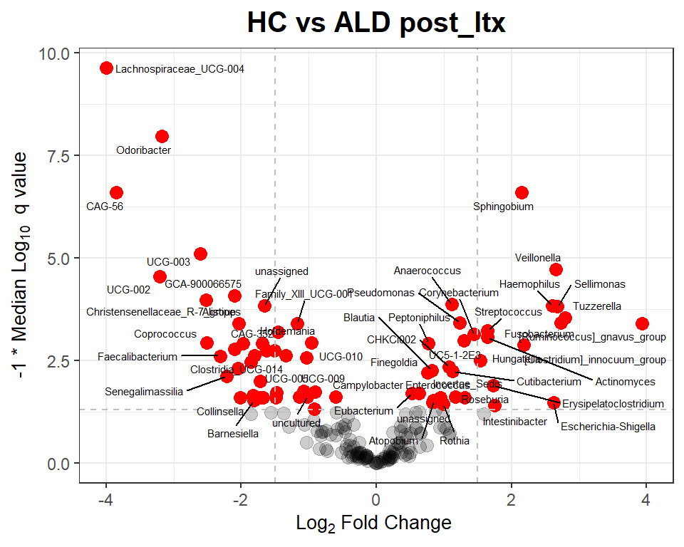

```r
# volcano plot
volcano <- volcano_plot_linda(linda.output, group1,
                                taxa_table = filt_colon_uni_taxa) +
            ggtitle(paste(group,collapse=" vs "))


# see the plot
volcano
```

###### 4.4.0.0.2.2 MaAsLin2

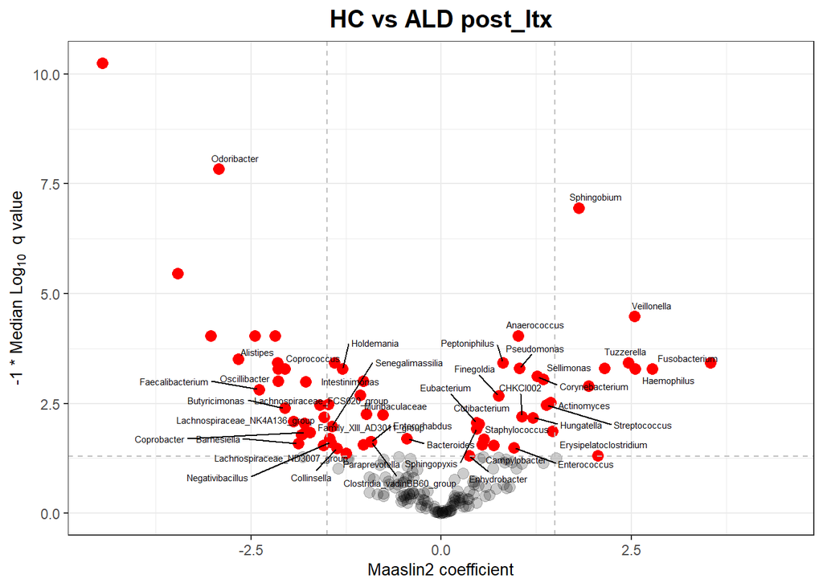

```r
volcano <- volcano_plot_maaslin(fit_data,filt_colon_uni_taxa) +
            ggtitle(paste(group[1], "vs", group[2]))

volcano
```

###### 4.4.0.0.2.3 Group - Intersection

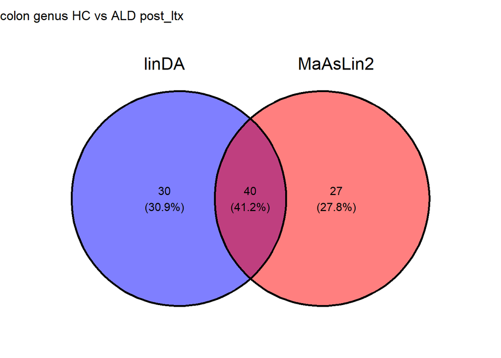

```r
intersection_results <- group_intersection(group, list_intersections, list_venns,
                                           linda.output, fit_data,
                                           raw_linda_results_genus,
                                           segment = segment,
                                           level=level)

list_intersections <- intersection_results[[1]]
list_venns <- intersection_results[[2]]
venn <- intersection_results[[3]]

# show the results
venn
```

###### 4.4.0.0.2.4 Basic statistics

```r
uni_df <-  merge(basic_univariate_statistics(linda_data,group),
                 raw_linda_results_genus[[segment]][[group1]],
                 by="SeqID",all=TRUE)
```

```
[1] "HC"
[1] "ALD post_ltx"
[1] "HC"
[1] "ALD post_ltx"
```

```r
uni_df[["final_sig"]] <- uni_df$SeqID %in% list_intersections[[paste(segment,level,comparison_name)]][["SeqID"]]
uni_statistics[[segment]][[paste(level,comparison_name)]] <- uni_df

# for comparison
new_name <- comparison_name
addWorksheet(wb, sheetName = new_name)
writeData(wb, sheet = new_name, uni_df, rowNames=FALSE)
```

###### 4.4.0.0.2.5 Comparison with PSC-associated taxa

```r
hc_ald_sig_colon <- uni_df %>%
  dplyr::filter(final_sig==TRUE) %>%
  dplyr::select(SeqID,Taxonomy,log2FoldChange)

psc_genus_colon <- psc_genus_colon
```

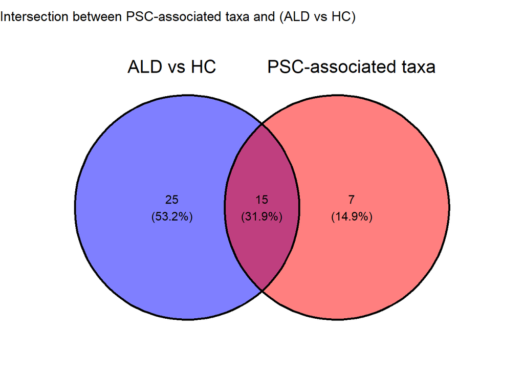

```r
list_core <- list()
list_core[["ALD vs HC"]] <- hc_ald_sig_colon$Taxonomy
list_core[["PSC-associated taxa"]] <- psc_genus_colon$Taxonomy

# venn diagram
venn <- ggvenn(list_core, fill_color = c("blue", "red")) +
    ggtitle("Intersection between PSC-associated taxa and (ALD vs HC)") +
    guides(fill = "none")

venn
```

From this Venn diagram, we are interested in EXLUSIVE RIGH JOIN

```r
A <- list_core$`ALD vs HC`
B <- list_core$`PSC-associated taxa`
remaining_psc <- B[!(B %in% A)]

psc_genus_colon %>%
  dplyr::filter(Taxonomy %in% remaining_psc)
```

```
              SeqID
1            Rothia
2   Parabacteroides
3  Fusicatenibacter
4 Lachnoclostridium
5  Colidextribacter
6         Dialister
7        Klebsiella
                                                                                                      Taxonomy
1               k__Bacteria;p__Actinobacteriota;c__Actinobacteria;o__Micrococcales;f__Micrococcaceae;g__Rothia
2             k__Bacteria;p__Bacteroidota;c__Bacteroidia;o__Bacteroidales;f__Tannerellaceae;g__Parabacteroides
3             k__Bacteria;p__Firmicutes;c__Clostridia;o__Lachnospirales;f__Lachnospiraceae;g__Fusicatenibacter
4            k__Bacteria;p__Firmicutes;c__Clostridia;o__Lachnospirales;f__Lachnospiraceae;g__Lachnoclostridium
5           k__Bacteria;p__Firmicutes;c__Clostridia;o__Oscillospirales;f__Oscillospiraceae;g__Colidextribacter
6 k__Bacteria;p__Firmicutes;c__Negativicutes;o__Veillonellales-Selenomonadales;f__Veillonellaceae;g__Dialister
7 k__Bacteria;p__Proteobacteria;c__Gammaproteobacteria;o__Enterobacterales;f__Enterobacteriaceae;g__Klebsiella
  log2FoldChange      p_value         padj
1       1.842842 1.452081e-05 1.953709e-04
2      -3.568149 2.950689e-06 6.238599e-05
3      -1.917547 1.097200e-02 3.455012e-02
4      -1.736481 1.812625e-03 8.383390e-03
5      -1.624469 8.895010e-03 2.991958e-02
6       2.144460 1.055678e-02 3.396528e-02
7       2.288824 1.471023e-03 7.257045e-03
```

```r
uni_df %>%
  dplyr::filter(Taxonomy %in% remaining_psc)
```

```
              SeqID Q1_clr HC Q1_clr ALD post_ltx     Q1_ra HC
1  Colidextribacter  1.386414           1.3243781 0.0006398704
2         Dialister -2.055467          -1.8464644 0.0000000000
3  Fusicatenibacter  2.627958          -0.9536309 0.0024423570
4        Klebsiella -2.173923          -2.1627708 0.0000000000
5 Lachnoclostridium  4.526164           4.3276317 0.0163044634
6   Parabacteroides  3.207395           1.7713357 0.0044359835
7            Rothia -2.019276          -1.6659988 0.0000000000
  Q1_ra ALD post_ltx MEDIAN_clr HC MEDIAN_clr ALD post_ltx MEDIAN_clr_ALL
1       0.0005364459     2.1904872               2.6123898      2.4197662
2       0.0000000000    -1.6466225              -1.5459890     -1.5933847
3       0.0000000000     3.7263000               3.4597865      3.6125117
4       0.0000000000    -1.9014687              -1.7576714     -1.8353611
5       0.0098512164     5.0769310               4.9156184      5.0561821
6       0.0005008488     3.8462676               3.5515723      3.7260301
```

[output cut: 57 more lines]